# modelo_LSTM

aire analytics

September 2, 2018

```r
#estaciones de calidad del Ayuntamiento de Madrid
#28079004 Pl España
#28079049 Retiro
estaciones_calidad_activas <- c('28079004','28079049')
```

```r
data <- read.csv2('28079004datos.csv', header = TRUE, sep = ',')
```

eliminamos NA

```r
data <- data[!is.na(data$cont8),]
```

eliminamos la columna X

```r
data <- data[,c('fecha','est3491','est6809','est4451','est4138','prec','presMax','presMin','racha',
                'velmedia','tmax','tmed','tmin','cont8')]
```

se selecciona el tipo de cada dato

```r
data$fecha <- as.Date(data$fecha)
data$est3491 <- as.numeric(data$est3491)
data$est6809 <- as.numeric(data$est6809)
data$est4451 <- as.numeric(data$est4451)
data$est4138 <- as.numeric(data$est4138)
data$prec <- as.numeric(data$prec)
data$presMax <- as.numeric(data$presMax)
data$presMin <- as.numeric(data$presMin)
data$racha <- as.numeric(data$racha)
data$velmedia <- as.numeric(data$velmedia)
data$tmax <- as.numeric(data$tmax)
data$tmed <- as.numeric(data$tmed)
data$tmin <- as.numeric(data$tmin)
data$cont8 <- as.numeric(data$cont8)
```

Incluimos el dato de tráfico agregado de los últimos 3 días

```r
data$trest3491 <-NA[]
data$trest6809 <-NA[]
data$trest4451 <-NA[]
data$trest4138 <-NA[]
```

```r
for (i in (4:nrow(data))){
  data$trest3491[i] <- as.numeric(data$est3491[i-1]) + as.numeric(data$est3491[i-2]) + as.numeric(data$est3491[i-3])
  data$trest6809[i] <- as.numeric(data$est6809[i-1]) + as.numeric(data$est6809[i-2]) + as.numeric(data$est6809[i-3])
  data$trest4451[i] <- as.numeric(data$est4451[i-1]) + as.numeric(data$est4451[i-2]) + as.numeric(data$est4451[i-3])
  data$trest4138[i] <- as.numeric(data$est4138[i-1]) + as.numeric(data$est4138[i-2]) + as.numeric(data$est4138[i-3])
}
```

Vamos a realizar la predicción sobrel el incremento de contaminación, por lo tanto lo que hacemos es generar una nueva variable que indica el incremento del contaminante sobre el día anterior

```r
data$incremento <-NA[]
```

```r
for (i in (2:nrow(data))){
  data$incremento[i] <- as.numeric(data$cont8[i]) - as.numeric(data$cont8[i-1])
}
```

normalizamos los datos eliminando la fila que no tiene incremento y no tienen tráfico acumulado

```r
dataNuevo <- data[!is.na(data$trest3491),]
dataNorm <- scale(dataNuevo[,2:19])
```

```r
datos = cor(dataNorm)
print(datos)
```

```
##                est3491     est6809     est4451       est4138         prec
## est3491     1.00000000  0.69415854  0.32541248  0.5768061465  0.011518957
## est6809     0.69415854  1.00000000  0.59785901  0.7569325731 -0.060110709
## est4451     0.32541248  0.59785901  1.00000000  0.6307786362 -0.037274170
## est4138     0.57680615  0.75693257  0.63077864  1.0000000000 -0.033850387
## prec        0.01151896 -0.06011071 -0.03727417 -0.0338503872  1.000000000
## presMax     0.12009081  0.04476147  0.02063804 -0.0195454026 -0.306190558
## presMin     0.07481338  0.02872697  0.00992338 -0.0488712956 -0.335742155
## racha      -0.02420571  0.04346936  0.05648803 -0.0009345973 -0.043240055
## velmedia   -0.07673271 -0.10365448 -0.12875079 -0.0285459032  0.087198055
## tmax       -0.14374581  0.01384075 -0.05449757  0.0049404705 -0.129430332
## tmed        0.01376057  0.04194963 -0.03733731 -0.0315705798 -0.064813718
## tmin        0.01783565 -0.07976922  0.06933389 -0.0401084962  0.044371729
## cont8       0.23858022  0.22392258  0.09974514  0.1311215019 -0.142632429
## trest3491   0.77109729  0.36621898  0.18424504  0.3027984672  0.047913623
## trest6809   0.40040291  0.52242868  0.38891923  0.3320489236 -0.008606487
## trest4451   0.15489535  0.32573348  0.76240233  0.2469738065 -0.027040285
## trest4138   0.37342191  0.42796975  0.39039596  0.4009782682  0.018154426
## incremento  0.10679540  0.16892786  0.11848262  0.1784079830 -0.150906878
##                presMax     presMin         racha    velmedia         tmax
## est3491     0.12009081  0.07481338 -0.0242057085 -0.07673271 -0.143745809
## est6809     0.04476147  0.02872697  0.0434693569 -0.10365448  0.013840747
## est4451     0.02063804  0.00992338  0.0564880283 -0.12875079 -0.054497567
## est4138    -0.01954540 -0.04887130 -0.0009345973 -0.02854590  0.004940471
## prec       -0.30619056 -0.33574215 -0.0432400545  0.08719806 -0.129430332
## presMax     1.00000000  0.94125429  0.1563603186 -0.39941781 -0.223288971
## presMin     0.94125429  1.00000000  0.2031491027 -0.45529237 -0.177047301
## racha       0.15636032  0.20314910  1.0000000000 -0.42132773  0.028267013
## velmedia   -0.39941781 -0.45529237 -0.4213277336  1.00000000  0.060984684
## tmax       -0.22328897 -0.17704730  0.0282670131  0.06098468  1.000000000
## tmed        0.08039361  0.04216519 -0.0558368734 -0.04454789  0.148057547
## tmin        0.10362153  0.07609099 -0.0325987130  0.05467870 -0.304047101
## cont8       0.41891087  0.44924569  0.2779916342 -0.55635093 -0.052134181
## trest3491   0.10797588  0.06223948 -0.0292535763 -0.09421129 -0.167739188
## trest6809   0.03026321  0.01638534  0.0679768462 -0.15052509 -0.021495495
## trest4451   0.02815014  0.02885632  0.1045944091 -0.18023660 -0.092706586
## trest4138  -0.05160569 -0.06943185  0.0556871977 -0.08596439 -0.033054855
## incremento  0.08054958  0.10728388  0.1355306847 -0.23299301  0.058623263
##                    tmed        tmin       cont8    trest3491    trest6809
## est3491     0.013760572  0.01783565  0.23858022  0.771097291  0.400402909
```

[output cut: 21 more lines]

```
## est4138     0.24697381  0.40097827  0.17840798
## prec       -0.02704028  0.01815443 -0.15090688
## presMax     0.02815014 -0.05160569  0.08054958
## presMin     0.02885632 -0.06943185  0.10728388
## racha       0.10459441  0.05568720  0.13553068
## velmedia   -0.18023660 -0.08596439 -0.23299301
## tmax       -0.09270659 -0.03305486  0.05862326
## tmed       -0.04748556 -0.07635111  0.05394731
## tmin        0.06502059 -0.05934151 -0.05959688
## cont8       0.00614485  0.02697395  0.46234219
## trest3491   0.28430170  0.58743537 -0.05711582
## trest6809   0.59324058  0.79832360 -0.09351839
## trest4451   1.00000000  0.61075941 -0.04532285
## trest4138   0.61075941  1.00000000 -0.07962689
## incremento -0.04532285 -0.07962689  1.00000000
```

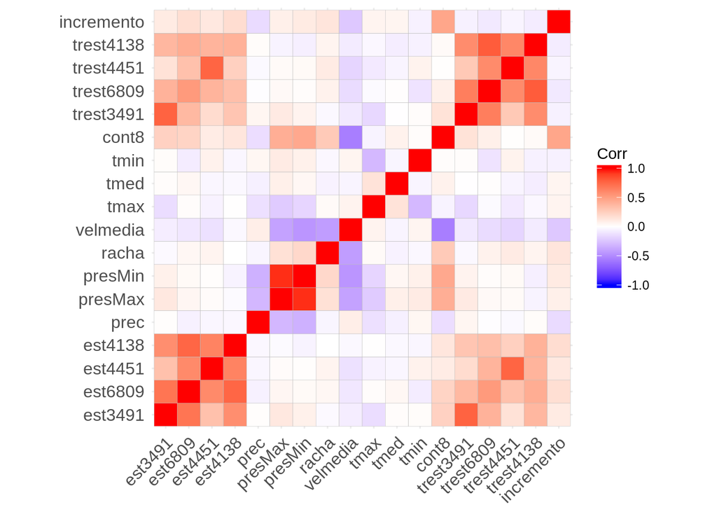

```r
library(ggcorrplot)
ggcorrplot(datos)
```

creamos una matriz con los datos normalizados que influyen en la contaminacion y nos quedamos con el incremento de contaminante

```r
dataModelo <- dataNorm[, c('est3491','est6809','est4451','est4138','trest3491','trest6809','trest4451','trest4138','prec','velmedia','cont8','incremento')]
```

se añade la fecha

```r
dataModelo <- cbind(as.Date(dataNuevo$fecha), dataModelo)
```

```r
colnames(dataModelo)[1] <- 'fecha'
```

Representamos gráficamente las variables en el tiempo con el factor de contaminación para ver las realaciones

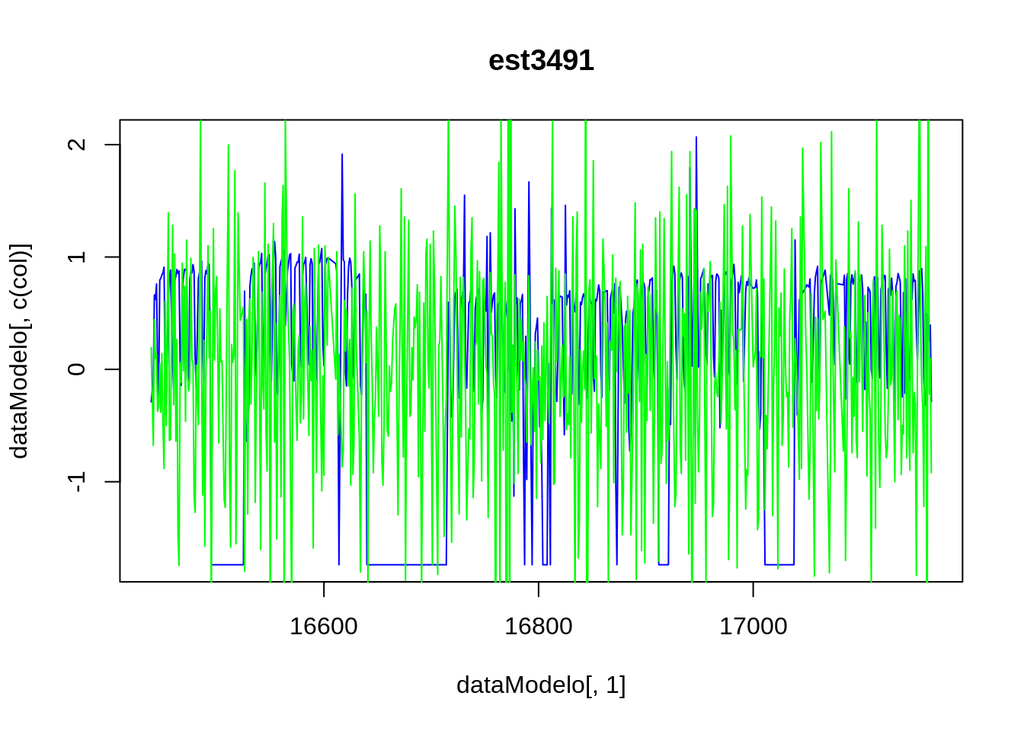

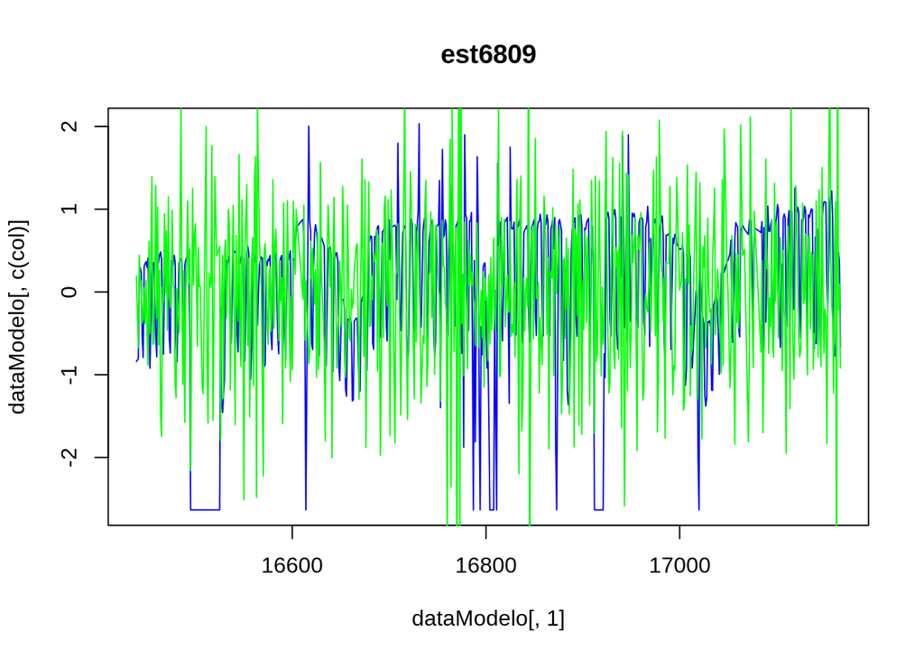

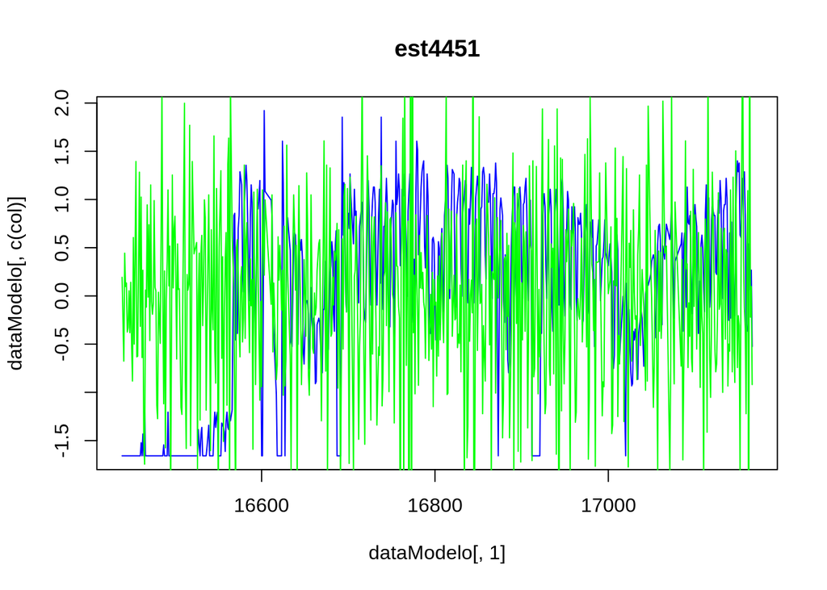

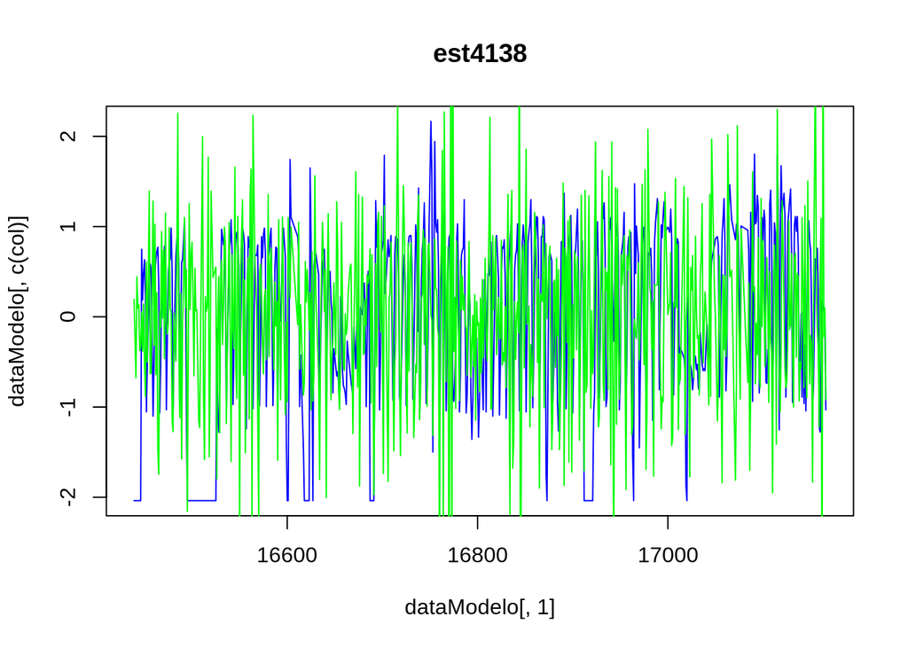

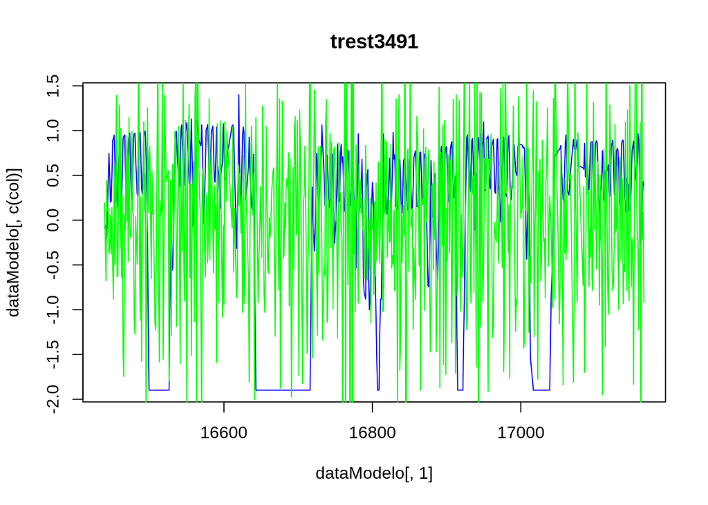

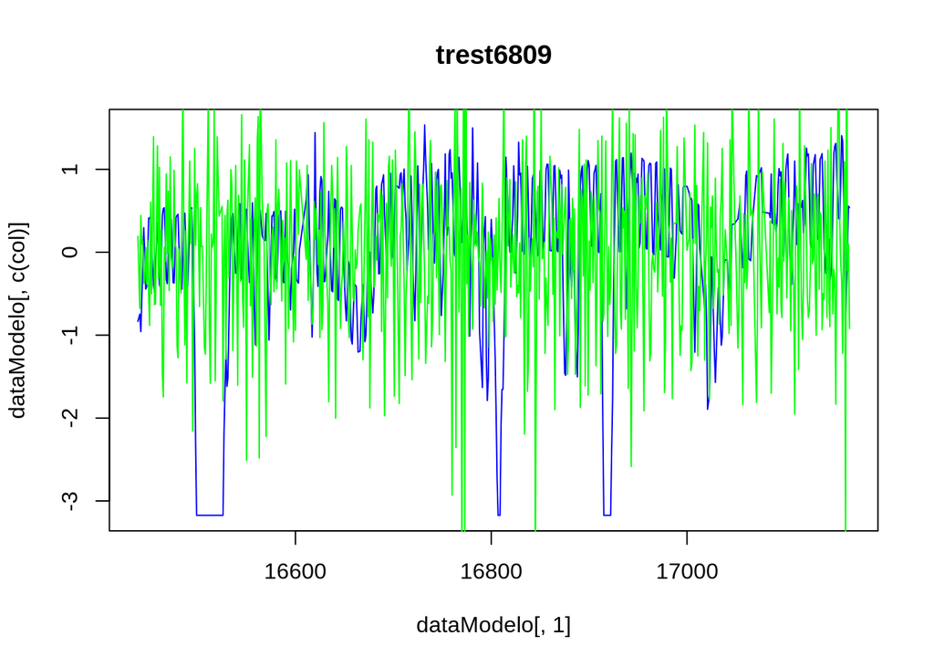

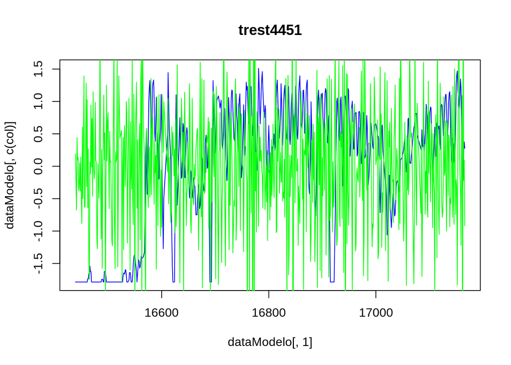

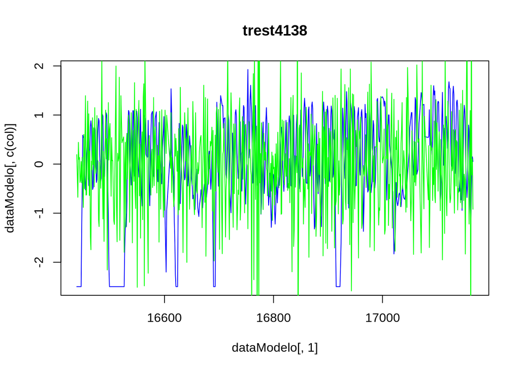

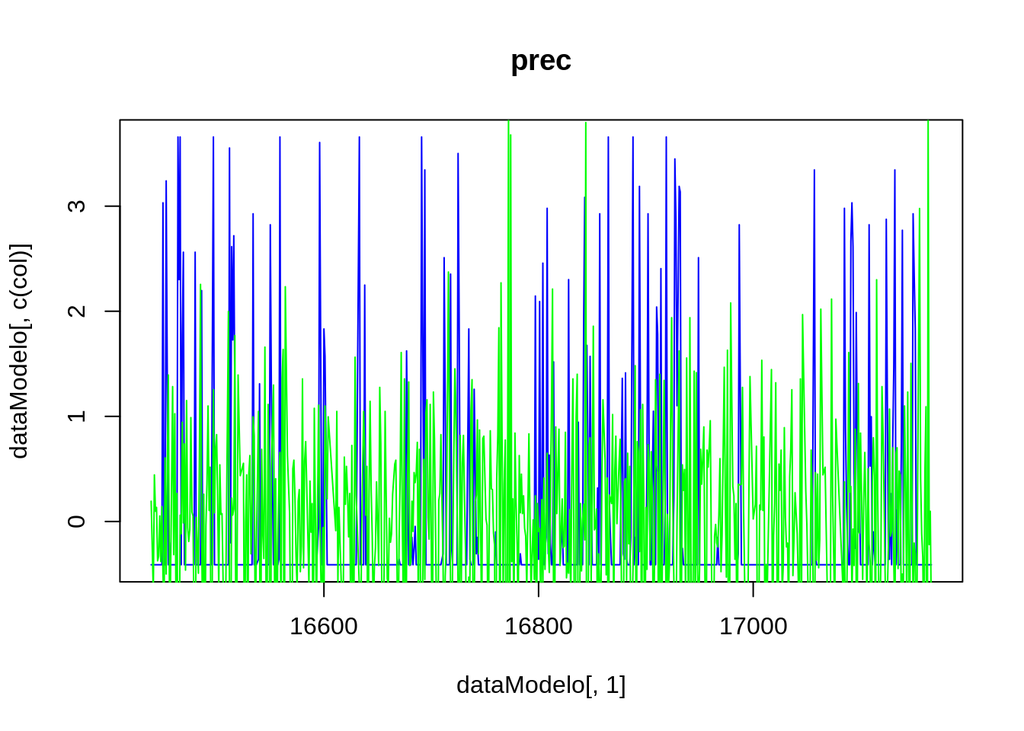

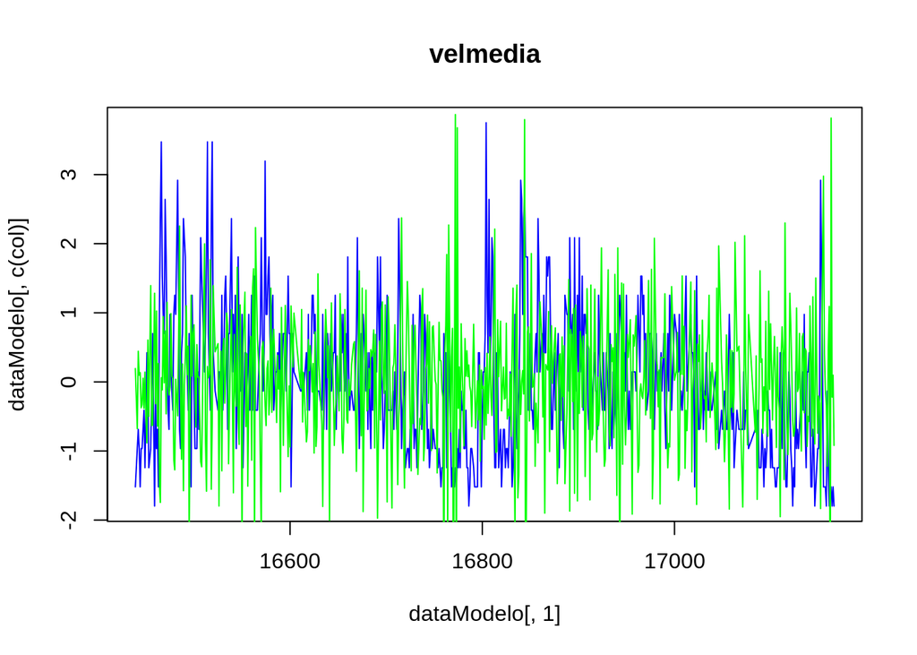

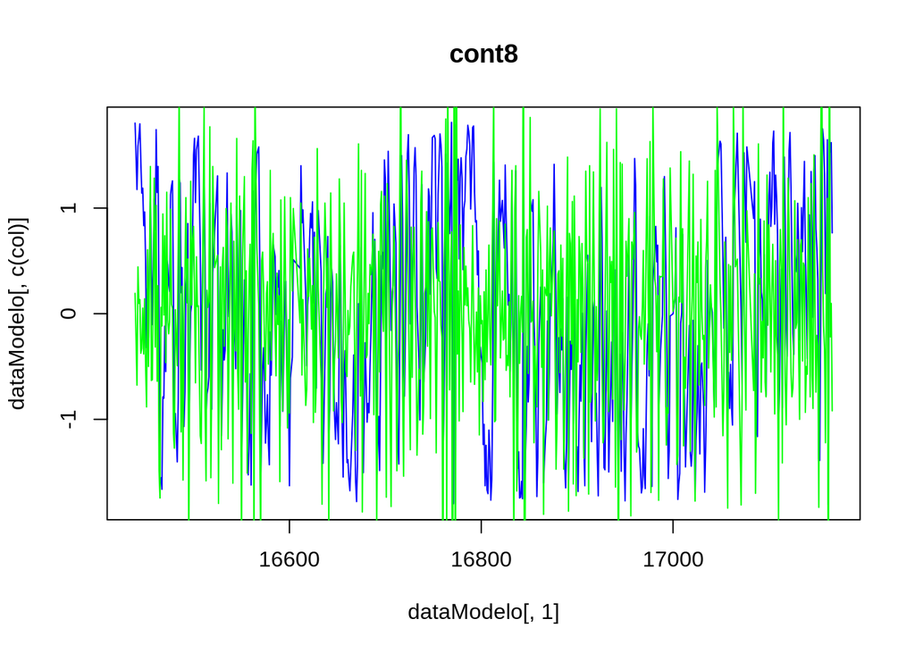

```r
for (col in (2:12)){
  plot(x=dataModelo[,1], y=dataModelo[,c(col)], type = "l", main = colnames(dataModelo)[col], col='blue')
  lines(x=dataModelo[,1], y=dataModelo[,13], col='green')
}
```

```r
library(ROCR)
library(caTools)
```

Sobre el Dataset de datos históricos vamos a construir un modelo que permita la prediccións. Para poder construir un modelo necesitamos contar con un conjunto de datos de entrenamiento que nos permitan aprender los patrones incluidos en los datos. Para seleccionar entre los modelos y poder asegurar que los patrones aprendidos son generalizables necesitamos valorar nuestros modelos en un conjunto de validación.

Por último debemos contar con un conjunto de test que nos permita establecer la capacidad predictiva del modelo elegido, este conjunto no debe utilizarse durante el proceso de construcción y validacion del modelo.

Primero se divide el conjunto total en dos conjuntos:

```r
dfModelo <- data.frame(dataModelo)
set.seed(1234)
n <- nrow(dfModelo)
muestra  <- sample(n, n * .70)
train    <- dfModelo[muestra, ]
test     <- dfModelo[-muestra, ]
```

De forma que tenemos 2 conjuntos train y test

```r
dim(dfModelo)
```

```
## [1] 640  13
```

```r
dim(train)
```

```
## [1] 448  13
```

```r
dim(test)
```

```
## [1] 192  13
```

### Bloque de Construcción de Modelos

```r
#modelo de regresión lineal múltiple
modelo <- lm(formula = 'incremento ~ est3491 + est6809 + est4451 + est4138 + trest3491 + trest6809 + trest4451 + trest4138 + prec + velmedia + cont8' ,data=train)
```

Ahora vamos a verificar si hace una predicción correcta

```r
prediccionRN   <- predict(modelo, test[,1:12])
```

```r
resultado <- data.frame(real = test[,12], prediccion = prediccionRN)
resultado
```

```
##              real   prediccion
## 7    1.5854390643  0.440114748
## 8    1.6743286099  0.415123730
## 17   0.2384205650 -0.162961540
## 21   0.4777385725  0.250414784
## 22  -0.1034623029 -0.014357893
## 24   1.0862900772  0.135887472
## 30  -1.6077469214 -0.846086843
## 35  -0.1171376176  0.091029216
## 37   0.5187645166  0.158636029
## 38   0.4640632577 -0.065654762
## 39   0.2862841665  0.007743237
## 40   0.2110699355  0.176552754
## 42   1.2093679096  0.544687841
## 43   1.2572315111  0.536588786
```

[output cut: 178 more lines]

Verificamos de forma numérica si la predicción se ajusta al real

```r
resultado$desviacion=((resultado$real-resultado$prediccion)/resultado$real)
precision=1-abs(mean(resultado$desviacion))
precision
```

```
## [1] 0.9736067
```

vemos la suma del error cuadrático que es otro buen indicador

```r
sumsqe <- sum (((resultado$real-resultado$prediccion)^2)/nrow(test))
sumsqe
```

```
## [1] 0.341921
```

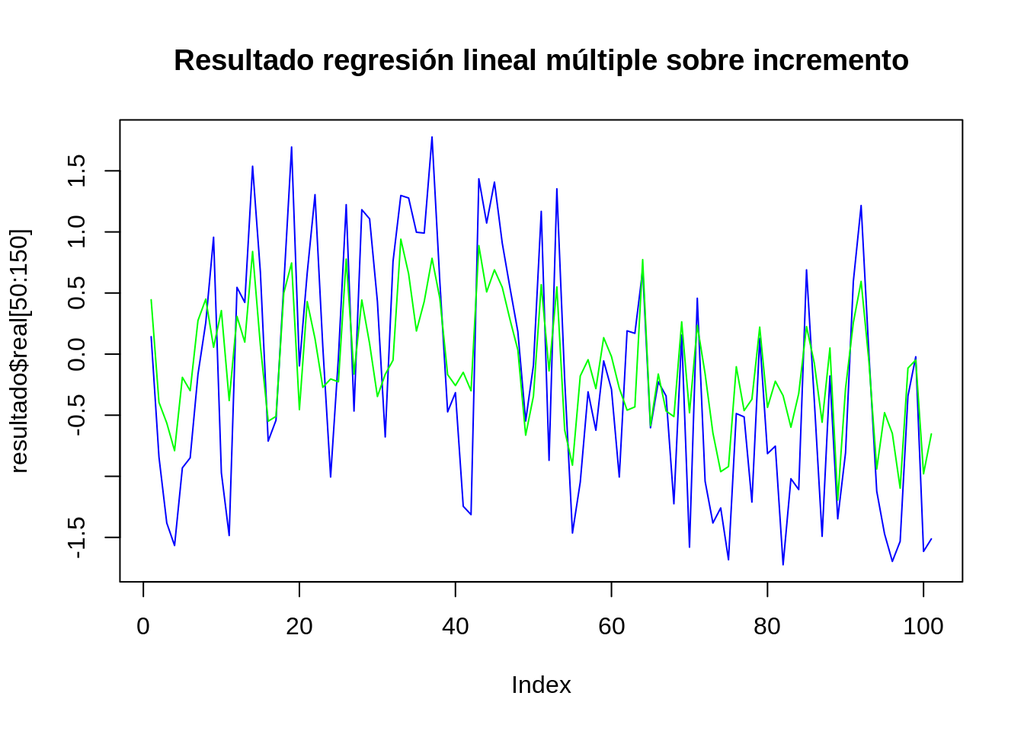

```r
plot(resultado$real[50:150], type = "l", main = "Resultado regresión lineal múltiple sobre incremento", col='blue')
lines(resultado$prediccion[50:150], col='green')
```